# 作業1

請依狀況更改上面的name,id及group（分別代表組員姓名，學號及組號），但請勿更改下面三行的設定。

姓名：蔡宗翰, 吳泓叡, 苗瑋中, 廖柏誠  
學號：710661104, 710661119, 710661117, 710661130  
組號：1

請直接在本檔案作答，存檔時也無需另存新檔名。交作業時，只由「組長」送出pull request給我。

作業除了讓同學檢視課堂所學程式外，有些題目只會給你未教過的函數建議（純為建議，你也可以不使用），你必需使用Help或網路查尋去了解函數的正確使用；搜詢正確程式函數使用的能力，也是程式設計的基本功。

如果是程式的答案，請設立如下的chunk區塊並在裡面作答

如果是文字答案，請設立沒有{r}的chunk區塊並在裡面作答。

```
你的文字答案。
```

# 教育與薪資

一開始請執行

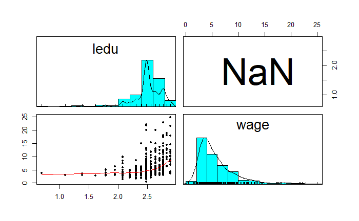

1. 請依據此[連結](http://fmwww.bc.edu/ec-p/data/wooldridge/wage1.des)說明wage1資料的來源及變數代表意義。[其中potential experience指得是推估工作經驗年資]

```
資料來源為Jeffrey M. Wooldridge

  1. wage                     平均時薪
  2. educ                     受教育年數
  3. exper                    推估工作經驗年資
  4. tenure                   最近從事的該份工作年資
  5. nonwhite                 判斷是否為白人
  6. female                   判斷是否為女性
  7. married                  判斷是否已婚
  8. numdep                   撫養人數
  9. smsa                     是否住在標準大都會
 10. northcen                 是否住在北美中心
 11. south                    是否住在美國南部
 12. west                     是否住在美國西部
 13. construc                 是否從事建築業
 14. ndurman                  是否從事非耐久財製造業
 15. trcommpu                 是否從事公共交通運輸業
 16. trade                    是否從事批發或零售業
 17. services                 是否從事加工製造業
 18. profserv                 是否從事專業加工製造
 19. profocc                  是否為教授
 20. clerocc                  是否為白領階級
 21. servocc                  是否從事服務業
```

我們想要問：“教育年限增加一年對勞動薪資的影響有多少？”

2. 請使用`psych::pairs.panels()`來描述教育年限(educ)與勞動薪資(wage)間的特質。在兩者的相關度上，有沒有那個變數取對數(log)會比較好？為什麼？

[output not shown]

[output not shown]

[output not shown]

[output not shown]

```
wage再取完對數後，相關係數變高(其他則會出現NaN)，故我們可以拿lwage來分析。
```

3. 請使用OLS估計以下的迴歸模型：
   $$log(wage)=\beta_0+\beta_1 educ+\epsilon$$

```r
wage1 %>% lm(lwage~educ,data=.)
```

4. 從資料裡選出兩個可能造成$\beta_1$OLS估計值帶有選擇性偏誤的變數，請說明理由並加以適當敍述統計量佐證。

```r
corr <- function(x) cor(x,wage1$educ)
wage1 %>%
  summarise_all(corr)
```

```
從結果中，我們挑了兩個與教育相關係數較大者來探討。
其中教授本身，本來就與受教育程度呈現相當正向的關係。
另外我們發現，另外，若工作經驗年資較高表示，較為提早進入職場，故與教育程度有相當的負向關係。
```

5. 延續上題，請完成對應複迴歸模型的估計。

```r
wage1 %>%
  lm(lwage~educ+exper+profocc,data=.)
```

6. 大致說來，教育年限12年表示高中畢業，大學畢業會有16年的教育，請問介於12年以上-16年以下的教育年限代表什麼？

```
表示就讀大學期間中突然休學，進入職場者。其可能主要原因可能為無法應付課業壓力。
```

7. 取出教育年限介於12-16年（含上下限）的資料，分別計算以下三群教育年限勞動者的平均薪資：12年，13-15年，16年。 [hint: dplyr::filter(), dplyr::group_by(), dplyr::summarise(), cut()]

```r
wage1 %>%
   mutate(type=cut(wage1$educ,breaks=c(0,13,16,100),labels=c("low","med","high"),right = FALSE))->wage1
  group_by(wage1,type) %>%
  summarise(mean(wage))
```

[output not shown]

8. 在下一部份的文章閱讀練習裡，文章提到:

> In a comparison of the earnings of people with degrees and people without them, those who start university but do not finish are lumped in with those who never started, even though they, too, will have paid fees and missed out on earnings. Their numbers are considerable.

在問題7中我們計算了三群人的平均薪資。請問若要避免文章所描述的問題，你會如何計算一位高中生若選擇上大學他會得到的預期薪資好處。[只使用問題7的數字及三群人人數]

$$log(wage)=\beta_0+\beta_1 C+\beta_2 G+\epsilon$$

令  
C = 0 為未進入大學 ,C=1 為進入大學

G = 0 為大學沒有畢業,G= 1 為大學有畢業

其中,

$\beta_1$為進入大學對薪資的效果
$\beta_2$為大學畢業對薪資的效果
$$E[lwage|C=0,G=0]=\beta_0 \ -(1)$$
$$E[lwage|C=1,G=0]=\beta_0+\beta_1\ -(2)$$
$$E[lwage|C=1,G=1]=\beta_0+\beta_1+\beta_2\ -(3)$$

# 文章閱讀

[Going to university is more important than ever for young people. But the financial returns are falling.](https://www.economist.com/news/international/21736151-financial-returns-are-falling-going-university-more-important-ever)

文章中有不少效應評估問句，及造成其無法直接進行簡單迴歸估計的選擇性偏誤原因，請將所有這樣的段落貼過來、寫下它的效應評估問句及造成選擇性偏誤的原因。例如：

[output not shown]

```
"Policymakers regard it as obvious that sending more young people to university will boost economic growth and social mobility."

評估問句：
國民越多人去念大學，經濟越好？

偏誤原因：
有錢的國家，有更多人去念大學，單單可能只是因為有"多餘"的錢或較少經濟壓力。
```

[output not shown]

[output not shown]